# Probability Distributions (and how they can arise in genetics)

```r
library(ggplot2)
library(reshape2)
set.seed(12345)
```

## Probability Distribution

### Probability Mass Function

The probability mass is a measure of where in a distribution the probability is. It is only defined for discrete distributions. Consider the probability mass for this observing genotype two minor alleles in HWE with an MAF of .5:

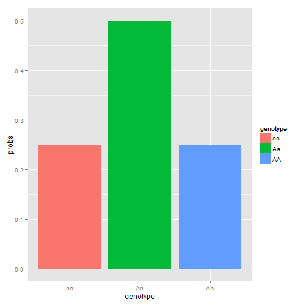

```r
probs <- data.frame(genotype = c("AA", "Aa", "aa"), probs = c(0.25, 0.5, 0.25))
ggplot(probs, aes(x = genotype, y = probs, fill = genotype)) + geom_bar(stat = "identity")
```

Most of the probability in this distribution is in 'Aa' and that makes sense because both 'A' and 'a' are equally common but theres two different ways to get 'Aa': Aa and aA. Now look at a rarer (A) allele in HWE.

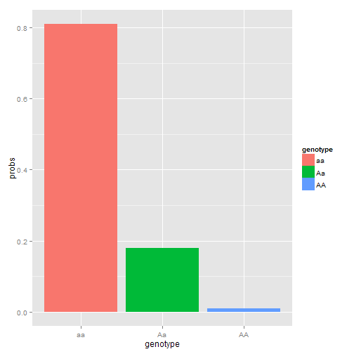

```r
p <- 0.1
probs <- data.frame(genotype = c("AA", "Aa", "aa"), probs = c(p^2, 2 * p * (1 -
    p), (1 - p)^2))
ggplot(probs, aes(x = genotype, y = probs, fill = genotype)) + geom_bar(stat = "identity")
```

Most of the probability here is in 'aa' because the A allele is so rare, that most of the probability is in observing an 'aa' genotype.

### Probability Density Function

Continuous distributions don't have probability mass functions, because the probability of observing a value infinitely precise to fit a specific point on a distribution is very small. Instead they have probability density functions, which give relative amounts of probability at a point. To find the actual probability within a region of a distribution you have to integrate over a certain region in the distribution (i.e. use the CDF.)

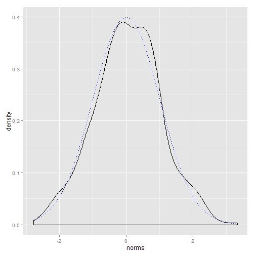

```r
norms <- rnorm(1000)
ggplot(as.data.frame(norms), aes(x = norms)) + geom_density() + stat_function(fun = dnorm,
    color = "blue", lty = "dotted")
```

### Expected Value

The expected value (or mean) of a distribution is the mean of all outcomes weighted by the probability of that outcome occurring (or probability densities for a continuous distribution). It effectively describes what value would be most common after sampling infinitely many times from the distribution. Here the expected value of the normal distribution is highlighted in red. The sample mean may not fall on the red line, but if you kept sampling, it would fall there eventually (this is called the law of large numbers).

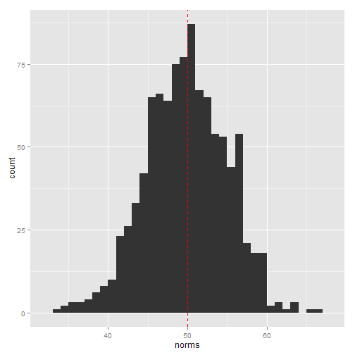

```r
mu <- 50
sigma <- 5
norms <- rnorm(1000, mean = mu, sd = sigma)
ggplot(as.data.frame(norms), aes(x = norms)) + geom_histogram(binwidth = 1) +
    geom_vline(xintercept = mu, color = "red", lty = "dashed")
```

### Variance

The variance describes how far away from the expected value that the values are spread in the distribution.

## Distributions in R

R has these functions built in for most common distributions. Each distribution has a root name. The root name for the normal distribution is 'norm'. The individual functions are then called by their letter followed by the root name:

- `pnorm` is the normal CDF.
- `qnorm` is the normal inverse CDF
- `dnorm` is the normal PDF
- `rnorm` generates a random variable from a normal distribution.

## A note on graphics

All of these distributions have a mathematical function that probabilities can be obtained with. However I've chosen here to instead sample variables from a distribution, and then plot the density of the sample. I think this is useful because in real world situations you won't have an infinite sample of datapoints, and your data may have odd lumps that occur by chance. If you take larger and larger samples, the distribution of the datapoints will more clearly represent the equation for the distribution. The blue represents the distribution of the sample, while the red represents the actual distribution it's drawn from.

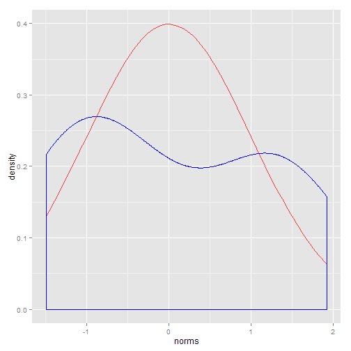

```r
# 10 Datapoints: looks pretty non normal.
norms <- rnorm(10)
ggplot(as.data.frame(norms), aes(x = norms)) + geom_density(color = "blue",
    alpha = 3/4) + stat_function(fun = dnorm, color = "red", alpha = 3/4)
```

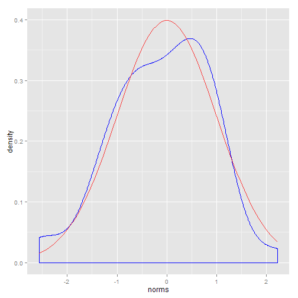

```r
# 50 Datapoints: we're getting there!
norms <- rnorm(50)
ggplot(as.data.frame(norms), aes(x = norms)) + geom_density(color = "blue",
    alpha = 3/4) + stat_function(fun = dnorm, color = "red", alpha = 3/4)
```

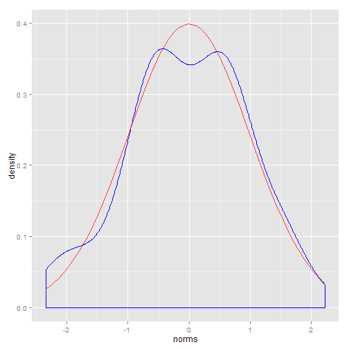

```r
# 100 Datapoints: not too shabby.
norms <- rnorm(100)
ggplot(as.data.frame(norms), aes(x = norms)) + geom_density(color = "blue",
    alpha = 3/4) + stat_function(fun = dnorm, color = "red", alpha = 3/4)
```

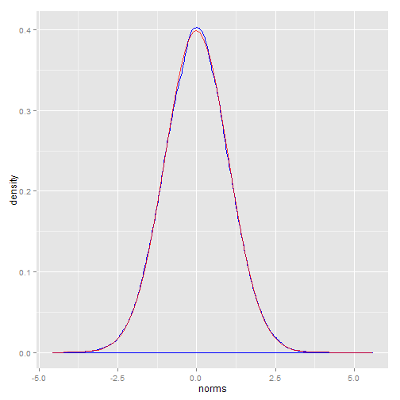

```r
# 10^5 Datapoints: pretty normal!
norms <- rnorm(10^5)
ggplot(as.data.frame(norms), aes(x = norms)) + geom_density(color = "blue",
    alpha = 3/4) + stat_function(fun = dnorm, color = "red", alpha = 3/4)
```

## The Central Limit Theorem

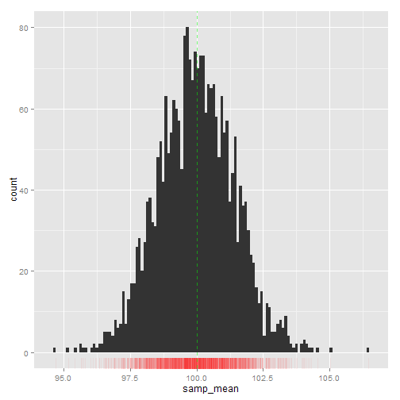

```r
popn <- rnorm(1e+06, mean = 100, sd = 10)
samp_mean <- numeric(0)
for (x in 1:2500) {
    samp_mean[x] <- mean(sample(popn, 50))
}
ggplot(as.data.frame(samp_mean), aes(x = samp_mean)) + geom_histogram(binwidth = 0.1) +
    geom_rug(color = "red", alpha = 0.05) + geom_vline(xintercept = 100, color = "green",
    alpha = 0.5, lty = "dashed")
```